# Data_Wrangling_Final

Shengtao Lin

3/30/2021

```r
library(tidyverse)
```

```r
library(tidyr)
library(broom)
library(ggplot2)
library(tidytext)
library(textdata)
library(tm)
library(rtweet)
library(here)
library(maps)
library(ggthemes)
library(textmineR)
library(MASS)
library(topicmodels)
```

```r
#api information
appname <- "DataWranglingFinal"
key <- "MaD1BxAxkamvNlQlkuEYr5xZW"
secret<-"OoItZw4daDAWGRcfKRHe9OlCUXyiJWR3ND4cGPmZ9W5kHG66yT"
accessToken="1190435999551303680-K6w06USFl27dt1Mkwj68jCA9c1LM0j"
accessSecrete="0v5eEUvq1ZhlUpuru9lK0SVbgyKH5nTIL22L4TsIcENRn"
```

```r
#Sends request to generate twitter token
twitter_token <- create_token(
  app = appname,
  consumer_key = key,
  consumer_secret = secret,
  access_token = accessToken,
  access_secret = accessSecrete)
```

Collect data with hashtag #StopAsianHate and #Vaccine. Each 10000 posts, does not include retweet, set language to English.

```r
# this is commented to prevent recollect data
#original_tweets_SAH <- search_tweets(q = "#StopAsianHate",n = 10000,include_rts = FALSE,lang = "en")
#original_tweets_Vaccine <- search_tweets(q = "#Vaccine",n = 10000,include_rts = FALSE,lang = "en")
```

Store the original data with columns we want to study.

```r
#generate coord
#commented to knit

#original_tweets_SAH<-lat_lng(original_tweets_SAH, coords = c("coords_coords", "bbox_coords", "geo_coords"))

#original_tweets_SAH_subset<-original_tweets_SAH%>%select(user_id,status_id,screen_name,text,source,country,name,location,lat,lng,created_at)

#write.csv(original_tweets_SAH_subset,"/Users/LINHTS/Documents/GitHub/Twitter_Data_Analysis/original_tweets_SAH.cvs")

#original_tweets_Vaccine<-lat_lng(original_tweets_Vaccine, coords = c("coords_coords", "bbox_coords", "geo_coords"))

#original_tweets_Vaccine_subset<-original_tweets_Vaccine%>%select(user_id,status_id,screen_name,text,source,country,name,location,lat,lng,created_at)

#write.csv(original_tweets_Vaccine_subset,"/Users/LINHTS/Documents/GitHub/Twitter_Data_Analysis/original_tweets_Vaccine.cvs")
```

Load the data from csv file

```r
df_SAH_ori <- read.csv("original_tweets_SAH.cvs")
df_Vac_ori <-read.csv("original_tweets_Vaccine.cvs")
head(df_SAH_ori)
```

|  | X | user_id | status_id | screen_name | text | source | country | name | location | lat | lng | created_at |
| --- | --- | --- | --- | --- | --- | --- | --- | --- | --- | --- | --- | --- |
| 1 | 1 | 6.847309e+07 | 1.384241e+18 | DavidWalkerCLT | They threw a #StopAsianHate hashtag and they go on to throw smears at an Asian guy in ways that they only reserve for Republicans they deem racist.\n\nThink about it guys. Why you think I left the lef… | Twitter Web App | NA | David Walker: Universal Basic Polling Machine\U0001f643 | My Computer | NA | NA | 2021-04-19 20:20:51 |
| 2 | 2 | 4.220713e+08 | 1.384240e+18 | mapault | Minnesota Police Zip-Tied Asian-American CNN Producer, Asked if She Spoke English, Says Lawyer https://t.co/T5NrnRdOjA @vp @MnDPS_MSP @GovTimWalz #StopAsianHate | Twitter Web App | NA | 420 somewhere |  | NA | NA | 2021-04-19 20:16:41 |
| 3 | 3 | 1.017463e+18 | 1.384239e+18 | QnsBPRichards | TOMORROW: #StopAsianHate is not a saying, it's our duty. Whether you've personally experienced hate or not, join us at 6:30pm and learn about the numerous resources available for both survivors and up… | Twitter Web App | NA | Queens Borough President Donovan Richards | Queens, NY | NA | NA | 2021-04-19 20:14:51 |
| 4 | 4 | 1.017463e+18 | 1.384168e+18 | QnsBPRichards | #Queens is sick of this surge in hate crimes targeting our Asian American neighbors, but Queens is so grateful to have @RepGraceMeng leading the charge in DC to combat hate.\n\nWe agree with @SenSchum… | Twitter for iPhone | United States | Queens Borough President Donovan Richards | Queens, NY | 40.67088 | -73.83119 | 2021-04-19 15:34:15 |
| 5 | 5 | 1.315040e+18 | 1.384239e+18 | yupiwonagain | We told you #StopAsianHate was white propaganda. \n\nHere’s the proof:\n\n4-18-2021: Asians Attack Black Victim's Memorial https://t.co/Lf6ixVmWjd | Twitter for iPhone | NA | DC | With the truth. | NA | NA | 2021-04-19 20:14:27 |
| 6 | 6 | 1.371908e+18 | 1.384239e+18 | SCAMMYGRAMMYSO1 | How do y'all find this funny? \nThis is disgusting. #StopAsianHate #RacismIsNotComedy #racism #racismisntcomedy https://t.co/WwKlCjDfnb | Twitter for Android | NA | Taesidebitch |  | NA | NA | 2021-04-19 20:13:52 |

```r
head(df_Vac_ori)
```

|  | X | user_id | status_id | screen_name | text | source | country | name | location | lat | lng | created_at |
| --- | --- | --- | --- | --- | --- | --- | --- | --- | --- | --- | --- | --- |
| 1 | 1 | 3.754960e+09 | 1.384355e+18 | UnitedWayMartin | We're kicking off #VolunteerAppreciationWeek with a shoutout to our 50 medical and nonmedical volunteers that devoted 400 hours at @GoHealthyMartin #vaccine clinics to help our community rebuild, resp… | Sprout Social | NA | United Way Martin |  | NA | NA | 2021-04-20 03:55:17 |
| 2 | 2 | 9.075965e+17 | 1.384355e+18 | NerdyTomas | @kyleve \U0001f446This is so much me.\n\nI miss the people and am growing very weary of my #WFH life.\n\nI'd take some vacation days, but nothing would change and I'd be extra bored. \n\nThis situatio… | Twitter Web App | NA | Nerdy Tomas | California, USA | NA | NA | 2021-04-20 03:55:15 |
| 3 | 3 | 1.384263e+18 | 1.384355e+18 | BrightBlueSkie2 | So thankful for my vaccination today. Thank you scientists, educators, doctors, nurses, @JustinTrudeau I’m honoured to be a part of helping to keep my community safe from #COVID19 #vaccine | Twitter for iPhone | NA | BrightBlueSkies |  | NA | NA | 2021-04-20 03:54:23 |
| 4 | 4 | 1.278722e+18 | 1.384355e+18 | News_Updates_24 | Prime Minister @NarendraModi to meet vaccine manufacturers from both India &amp; abroad through video conferencing at 6 PM today.\n#vaccine | Twitter for Android | NA | News Updates |  | NA | NA | 2021-04-20 03:54:13 |
| 5 | 5 | 5.024351e+08 | 1.384354e+18 | MuslimObserver | Johnson and Johnson Vaccine Put on Hold\n#Johnson #Vaccine #TMO #themuslimobserver\nhttps://t.co/kwy6aF6TVx https://t.co/ngRiVDLjPG | Twitter Web App | NA | TMO Media | Farmington Hills, Michigan | NA | NA | 2021-04-20 03:53:14 |
| 6 | 6 | 8.055894e+17 | 1.384354e+18 | shantibants | @redundantuk @greggyjj @VickySeal https://t.co/GWNaugpsWD\n\nThis is the TGA report on AstraZeneca it's a hefty read but has some very useful references for following the trial schedule for Aus - pgs … | Twitter Web App | NA | Shanti | Australia | NA | NA | 2021-04-20 03:53:03 |

Start cleaning

```r
data("stop_words")
#SAH

df_SAH_ori<-df_SAH_ori%>%
  mutate(stripped_text=gsub("http.*","",  text))%>% #remove URL
  mutate(stripped_text=gsub("#\\w+ *","",  stripped_text))%>% #remove hash tag
  mutate(stripped_text=gsub("@\\w+ *","",  stripped_text))%>% #remove @
  mutate(stripped_text=gsub("\\(","",  stripped_text))%>% #remove ( and )
  mutate(stripped_text=gsub("\\)","",  stripped_text))%>%
  mutate(stripped_text = tolower(stripped_text))%>% #lower case
  mutate(stripped_text=gsub("[\r\n]", "",  stripped_text))%>% #remove new line
  mutate(stripped_text=gsub("&amp", "",  stripped_text))%>% #remove &amp
  mutate(stripped_text=gsub("[[:punct:]]+", "",  stripped_text))%>%#remove punctuation
  mutate(stripped_text=gsub("[[:digit:]]+", "",  stripped_text))#remove digits

#commented to knit
#write.csv(df_SAH_ori,"/Users/LINHTS/Documents/GitHub/Twitter_Data_Analysis/cleaned_tweets_SAH.cvs")


df_SAH_cleaned <- read.csv("cleaned_tweets_SAH.cvs")

df_SAH_cleaned1<-df_SAH_cleaned%>%unnest_tokens(word,stripped_text)%>%anti_join(stop_words)#remove stopwords
#Vac

df_Vac_ori<-df_Vac_ori%>%
  mutate(stripped_text=gsub("http.*","",  text))%>% #remove URL
  mutate(stripped_text=gsub("#\\w+ *","",  stripped_text))%>% #remove hash tag
  mutate(stripped_text=gsub("@\\w+ *","",  stripped_text))%>% #remove @
  mutate(stripped_text=gsub("\\(","",  stripped_text))%>% #remove ( and )
  mutate(stripped_text=gsub("\\)","",  stripped_text))%>%
  mutate(stripped_text = tolower(stripped_text))%>% #lower case
  mutate(stripped_text=gsub("[\r\n]", "",  stripped_text))%>% #remove new line
  mutate(stripped_text=gsub("&amp", "",  stripped_text))%>% #remove &amp
  mutate(stripped_text=gsub("[[:punct:]]+", "",  stripped_text))%>%#remove punctuation
  mutate(stripped_text=gsub("[[:digit:]]+", "",  stripped_text))#remove digits

#commented to knit
#write.csv(df_Vac_ori,"/Users/LINHTS/Documents/GitHub/Twitter_Data_Analysis/cleaned_tweets_Vac.cvs")


df_Vac_cleaned <- read.csv("cleaned_tweets_Vac.cvs")


df_Vac_cleaned1<-df_Vac_cleaned%>%unnest_tokens(word,stripped_text)%>%anti_join(stop_words)# remove stop words
```

cleaned the texts of tweets by removing URLs, hashtags, mentions, &amp, punctuations, and digits. Also convereted all letters to lower case and removed stop words.

```r
head(df_SAH_cleaned[,3:14])
```

|  | user_id | status_id | screen_name | text | source | country | name | location | lat | lng | created_at | stripped_text |
| --- | --- | --- | --- | --- | --- | --- | --- | --- | --- | --- | --- | --- |
| 1 | 6.847309e+07 | 1.384241e+18 | DavidWalkerCLT | They threw a #StopAsianHate hashtag and they go on to throw smears at an Asian guy in ways that they only reserve for Republicans they deem racist.\n\nThink about it guys. Why you think I left the lef… | Twitter Web App | NA | David Walker: Universal Basic Polling Machine\U0001f643 | My Computer | NA | NA | 2021-04-19 20:20:51 | they threw a hashtag and they go on to throw smears at an asian guy in ways that they only reserve for republicans they deem racistthink about it guys why you think i left the left it aint because the… |
| 2 | 4.220713e+08 | 1.384240e+18 | mapault | Minnesota Police Zip-Tied Asian-American CNN Producer, Asked if She Spoke English, Says Lawyer https://t.co/T5NrnRdOjA @vp @MnDPS_MSP @GovTimWalz #StopAsianHate | Twitter Web App | NA | 420 somewhere |  | NA | NA | 2021-04-19 20:16:41 | minnesota police ziptied asianamerican cnn producer asked if she spoke english says lawyer |
| 3 | 1.017463e+18 | 1.384239e+18 | QnsBPRichards | TOMORROW: #StopAsianHate is not a saying, it's our duty. Whether you've personally experienced hate or not, join us at 6:30pm and learn about the numerous resources available for both survivors and up… | Twitter Web App | NA | Queens Borough President Donovan Richards | Queens, NY | NA | NA | 2021-04-19 20:14:51 | tomorrow is not a saying its our duty whether youve personally experienced hate or not join us at pm and learn about the numerous resources available for both survivors and upstanderskeeping our famil… |
| 4 | 1.017463e+18 | 1.384168e+18 | QnsBPRichards | #Queens is sick of this surge in hate crimes targeting our Asian American neighbors, but Queens is so grateful to have @RepGraceMeng leading the charge in DC to combat hate.\n\nWe agree with @SenSchum… | Twitter for iPhone | United States | Queens Borough President Donovan Richards | Queens, NY | 40.67088 | -73.83119 | 2021-04-19 15:34:15 | is sick of this surge in hate crimes targeting our asian american neighbors but queens is so grateful to have leading the charge in dc to combat hatewe agree with the senate must pass the covid hate c… |
| 5 | 1.315040e+18 | 1.384239e+18 | yupiwonagain | We told you #StopAsianHate was white propaganda. \n\nHere’s the proof:\n\n4-18-2021: Asians Attack Black Victim's Memorial https://t.co/Lf6ixVmWjd | Twitter for iPhone | NA | DC | With the truth. | NA | NA | 2021-04-19 20:14:27 | we told you was white propaganda heres the proof asians attack black victims memorial |
| 6 | 1.371908e+18 | 1.384239e+18 | SCAMMYGRAMMYSO1 | How do y'all find this funny? \nThis is disgusting. #StopAsianHate #RacismIsNotComedy #racism #racismisntcomedy https://t.co/WwKlCjDfnb | Twitter for Android | NA | Taesidebitch |  | NA | NA | 2021-04-19 20:13:52 | how do yall find this funny this is disgusting |

```r
head(df_Vac_cleaned[,3:14])
```

|  | user_id | status_id | screen_name | text | source | country | name | location | lat | lng | created_at | stripped_text |
| --- | --- | --- | --- | --- | --- | --- | --- | --- | --- | --- | --- | --- |
| 1 | 3.754960e+09 | 1.384355e+18 | UnitedWayMartin | We're kicking off #VolunteerAppreciationWeek with a shoutout to our 50 medical and nonmedical volunteers that devoted 400 hours at @GoHealthyMartin #vaccine clinics to help our community rebuild, resp… | Sprout Social | NA | United Way Martin |  | NA | NA | 2021-04-20 03:55:17 | were kicking off with a shoutout to our medical and nonmedical volunteers that devoted hours at clinics to help our community rebuild respond and recover we are |
| 2 | 9.075965e+17 | 1.384355e+18 | NerdyTomas | @kyleve \U0001f446This is so much me.\n\nI miss the people and am growing very weary of my #WFH life.\n\nI'd take some vacation days, but nothing would change and I'd be extra bored. \n\nThis situatio… | Twitter Web App | NA | Nerdy Tomas | California, USA | NA | NA | 2021-04-20 03:55:15 | this is so much mei miss the people and am growing very weary of my lifeid take some vacation days but nothing would change and id be extra bored this situation is not ideal fortuantely the second is … |
| 3 | 1.384263e+18 | 1.384355e+18 | BrightBlueSkie2 | So thankful for my vaccination today. Thank you scientists, educators, doctors, nurses, @JustinTrudeau I’m honoured to be a part of helping to keep my community safe from #COVID19 #vaccine | Twitter for iPhone | NA | BrightBlueSkies |  | NA | NA | 2021-04-20 03:54:23 | so thankful for my vaccination today thank you scientists educators doctors nurses im honoured to be a part of helping to keep my community safe from |
| 4 | 1.278722e+18 | 1.384355e+18 | News_Updates_24 | Prime Minister @NarendraModi to meet vaccine manufacturers from both India &amp; abroad through video conferencing at 6 PM today.\n#vaccine | Twitter for Android | NA | News Updates |  | NA | NA | 2021-04-20 03:54:13 | prime minister to meet vaccine manufacturers from both india abroad through video conferencing at pm today |
| 5 | 5.024351e+08 | 1.384354e+18 | MuslimObserver | Johnson and Johnson Vaccine Put on Hold\n#Johnson #Vaccine #TMO #themuslimobserver\nhttps://t.co/kwy6aF6TVx https://t.co/ngRiVDLjPG | Twitter Web App | NA | TMO Media | Farmington Hills, Michigan | NA | NA | 2021-04-20 03:53:14 | johnson and johnson vaccine put on hold |
| 6 | 8.055894e+17 | 1.384354e+18 | shantibants | @redundantuk @greggyjj @VickySeal https://t.co/GWNaugpsWD\n\nThis is the TGA report on AstraZeneca it's a hefty read but has some very useful references for following the trial schedule for Aus - pgs … | Twitter Web App | NA | Shanti | Australia | NA | NA | 2021-04-20 03:53:03 |  |

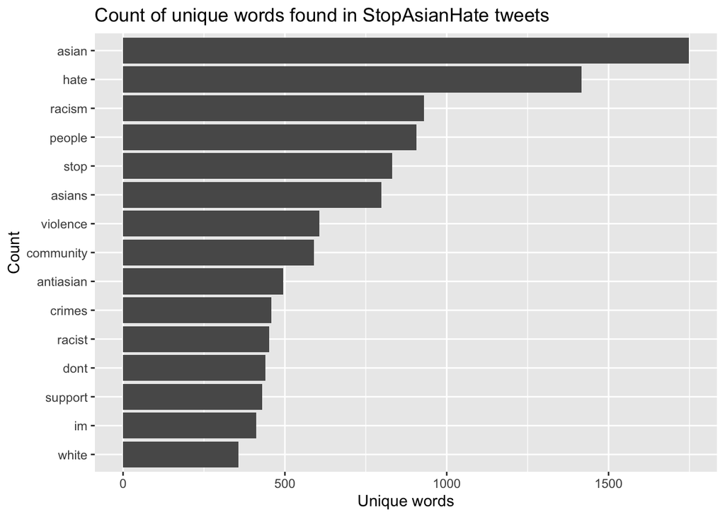

```r
#most common used words.

df_SAH_cleaned1 %>%
  count(word, sort = TRUE) %>%
  top_n(15) %>%
  mutate(word = reorder(word, n)) %>%
  ggplot(aes(x = word, y = n)) +
  geom_col() +
  xlab(NULL) +
  coord_flip() +
      labs(x = "Count",
      y = "Unique words",
      title = "Count of unique words found in StopAsianHate tweets")
```

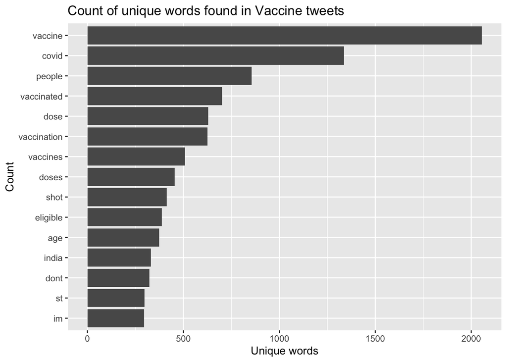

```r
df_Vac_cleaned1 %>%
  count(word, sort = TRUE) %>%
  top_n(15) %>%
  mutate(word = reorder(word, n)) %>%
  ggplot(aes(x = word, y = n)) +
  geom_col() +
  xlab(NULL) +
  coord_flip() +
      labs(x = "Count",
      y = "Unique words",
      title = "Count of unique words found in Vaccine tweets")
```

We can see for #StopAsianHate, asian, hate, racism, people, stop are most frequently used words.  
For #Vaccine, the words vaccine, covid, people, vaccinated, dose are most frequently used.

```r
# 3 grams analysis
df_SAH_ngram<-df_SAH_cleaned%>%
  dplyr::select(stripped_text) %>%
  unnest_tokens(pair,stripped_text,token = "ngrams", n = 3)

SAH_3grams<-df_SAH_ngram%>%
  separate(pair, c("word1", "word2","word3"), sep = " ")%>%
  filter(!word1 %in% stop_words$word) %>%
  filter(!word2 %in% stop_words$word) %>%
  filter(!word3 %in% stop_words$word) %>%
  count(word1, word2, word3, sort = TRUE)%>%
  drop_na()

SAH_3grams%>%top_n(10)
```

| word1 | word2 | word3 | n |
| --- | --- | --- | --- |
| covid | hate | crimes | 109 |
| stop | asian | hate | 90 |
| hate | crimes | act | 88 |
| antiasian | hate | crimes | 78 |
| hate | crimes | bill | 34 |
| asian | hate | crimes | 32 |
| julian | assange | matter | 29 |
| antiasian | hate | crime | 27 |
| anti | asian | racism | 26 |
| shooting | anti | asian | 26 |

We can see “covid hate crimes”, “stop asian hate”, “hate crime act”, are most common 3 grams.

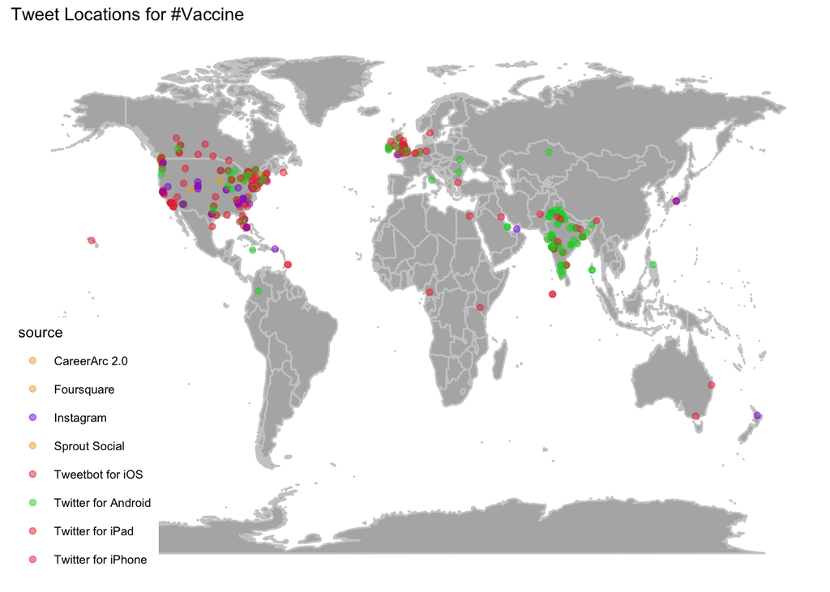

```r
#world map for #Vaccine
tweet_locations_Vac <- df_Vac_cleaned %>% na.omit()

world_basemap <- ggplot() +
  borders("world", colour = "gray80", fill = "gray70")+
  theme_map()+
  geom_point(data = tweet_locations_Vac, aes(x = lng, y = lat, color = source),  alpha = .5) +
  labs(title = "Tweet Locations for #Vaccine")+
  scale_color_manual(values=c("#ebae34", "#ebae34", "#8b19e3","#ebae34","#eb3443","#08d431","#eb3443","#eb3443"))

world_basemap
```

We can see the location of the #Vaccine tweets are mainly in US, Canada, UK, and India. Also we can see the decive people are using. People in US are using all different platforms, user in UK prefer IOS, and user in India prefer Android.

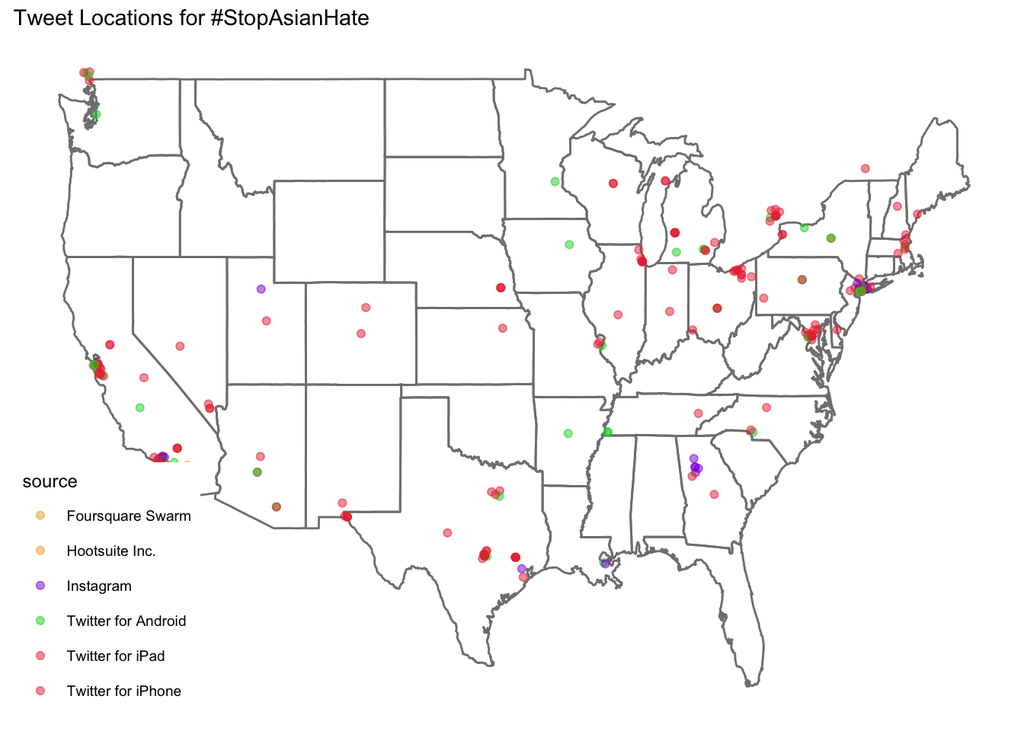

```r
#map for ASH in US
tweet_locations_SAH <- df_SAH_cleaned %>% na.omit()%>%filter(lng>=(-130),lng<=(-60),lat>=(20),lat<=(50))

us_basemap <- ggplot() +
  borders("state")+
  theme_map()+
  geom_point(data = tweet_locations_SAH, aes(x = lng, y = lat,colour = source), alpha = .5) +
  labs(title = "Tweet Locations for #StopAsianHate")+
  scale_color_manual(values=c("#ebae34", "#ebae34", "#8b19e3","#08d431","#eb3443","#eb3443"))

us_basemap
```

We can see the #StopAsianHate tweets are mainly located in major city in US. Also the majority of them use IOS device.

```r
bing_Vac_counts <- df_Vac_cleaned1 %>%
  inner_join(get_sentiments("bing")) %>%
  count(word, sentiment, sort = TRUE) %>%
  ungroup()
```

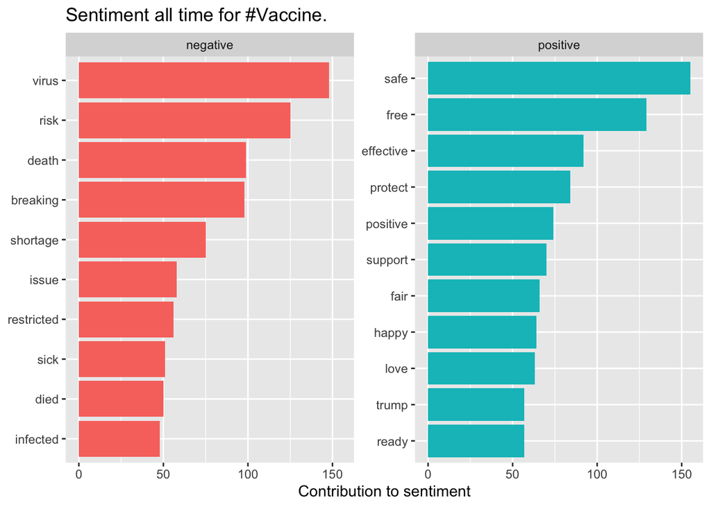

```r
bing_Vac_counts %>%
  group_by(sentiment) %>%
  top_n(10) %>%
  ungroup() %>%
  mutate(word = reorder(word, n)) %>%
  ggplot(aes(word, n, fill = sentiment)) +
  geom_col(show.legend = FALSE) +
  facet_wrap(~sentiment, scales = "free_y") +
  labs(title = "Sentiment all time for #Vaccine.",
       y = "Contribution to sentiment",
       x = NULL) +
  coord_flip()
```

For # Vaccine, the most negative word is virus and most common positive word is safe.

```r
bing_SAH_counts <- df_SAH_cleaned1 %>%
  inner_join(get_sentiments("bing")) %>%
  count(word, sentiment, sort = TRUE) %>%
  ungroup()
```

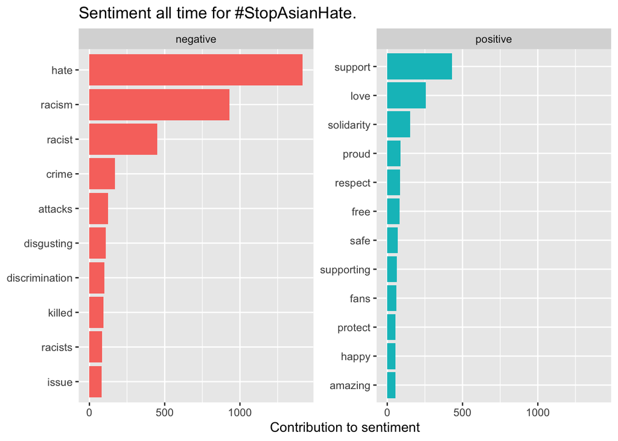

```r
bing_SAH_counts %>%
  group_by(sentiment) %>%
  top_n(10) %>%
  ungroup() %>%
  mutate(word = reorder(word, n)) %>%
  ggplot(aes(word, n, fill = sentiment)) +
  geom_col(show.legend = FALSE) +
  facet_wrap(~sentiment, scales = "free_y") +
  labs(title = "Sentiment all time for #StopAsianHate.",
       y = "Contribution to sentiment",
       x = NULL) +
  coord_flip()
```

For #StopAsianHate, the most common negative word is hate and positive word is support.

```r
Vac_sentiment<- df_Vac_cleaned1 %>%
  inner_join(get_sentiments("bing")) %>%
  mutate(index = format(as.POSIXlt(created_at),"%m%d%H"))%>%
  count(index,sentiment)%>%
  arrange(index)%>%
  pivot_wider(names_from = "sentiment",values_from="n")%>%
  mutate(sentiment= positive-negative)%>%
  mutate(pos = sentiment >= 0)
```

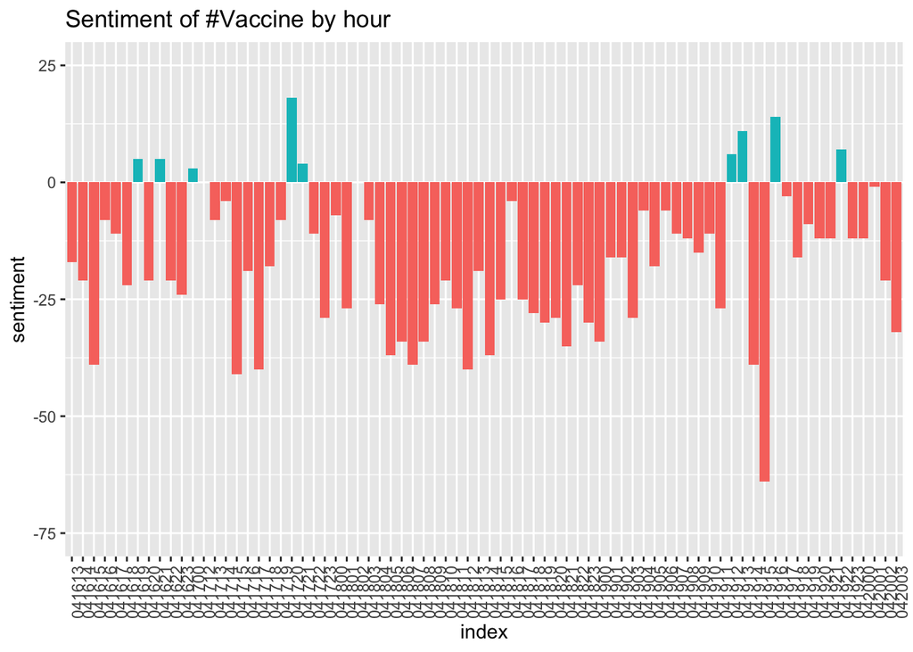

```r
ggplot(Vac_sentiment,aes(index,sentiment,fill = pos))+
  geom_bar(stat="identity")+theme(axis.text.x = element_text(angle=90))+
  theme(legend.position = "none")+
  labs(title="Sentiment of #Vaccine by hour")+
  ylim(c(-75,25))
```

```r
corpus <- Corpus(VectorSource(df_Vac_cleaned$stripped_text))
corpus <- tm_map(corpus, removeWords, stopwords("en"))
```

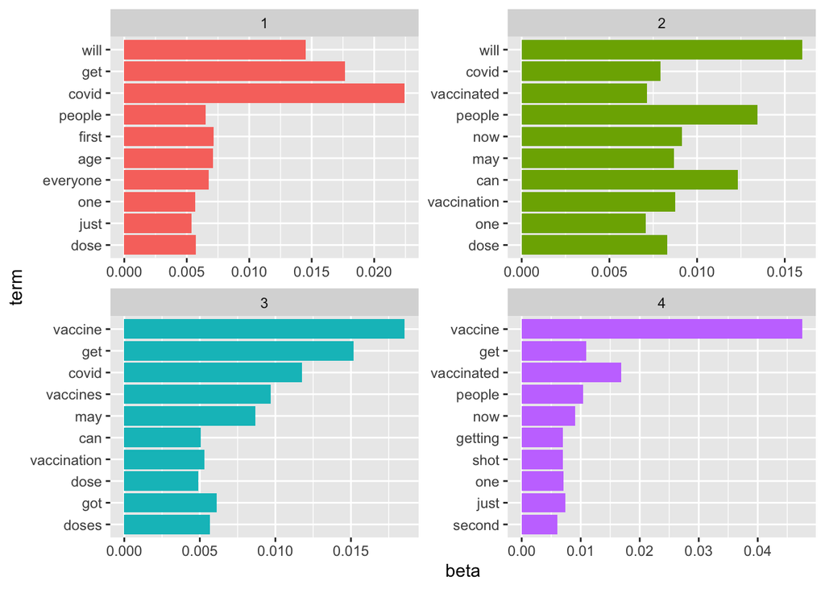

```r
doc.lengths <- rowSums(as.matrix(DocumentTermMatrix(corpus)))
dtm <- DocumentTermMatrix(corpus[doc.lengths > 0])

lda <- LDA(dtm, 4,control=list(seed=1234))


topics4 <- tidy(lda, matrix = "beta")

top_terms <- topics4 %>%
  group_by(topic) %>%
  top_n(10, beta) %>%
  ungroup() %>%
  arrange(topic, -beta)

top_terms%>%
  mutate(term = reorder(term, beta)) %>%
  ggplot(aes(term, beta, fill = factor(topic))) +
  geom_col(show.legend = FALSE) +
  facet_wrap(~ topic, scales = "free") +
  coord_flip()
```

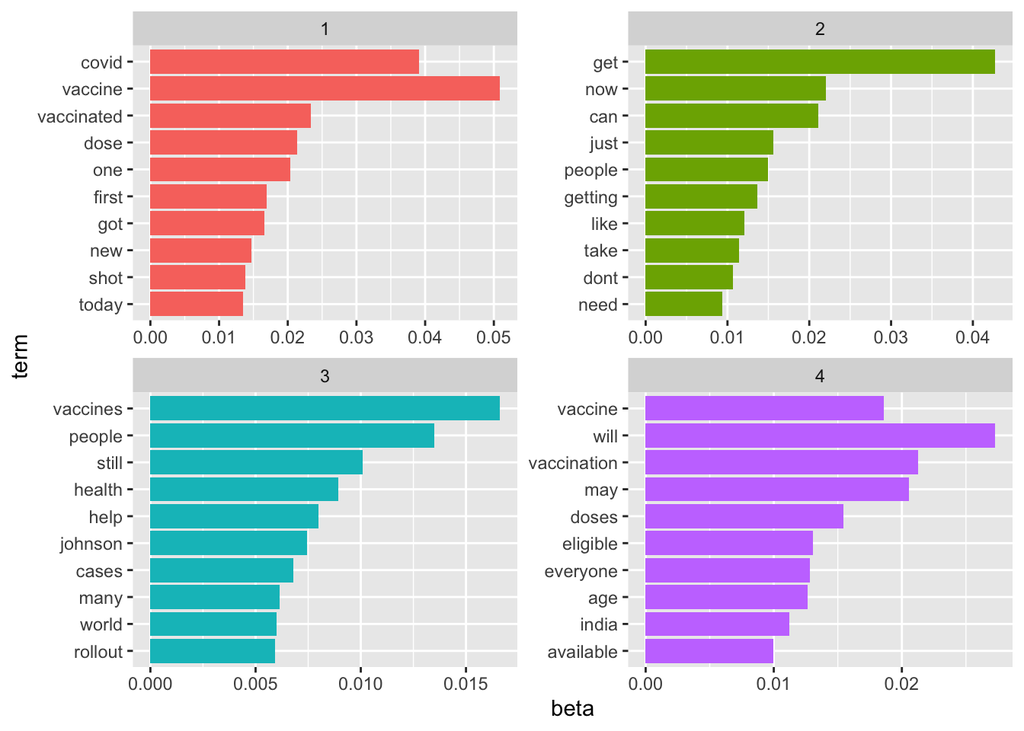

```r
lda_2 <-LDA(dtm,k=4,method="Gibbs", control=list(seed=1234))

topics4 <- tidy(lda_2, matrix = "beta")

top_terms <- topics4 %>%
  group_by(topic) %>%
  top_n(10, beta) %>%
  ungroup() %>%
  arrange(topic, -beta)

top_terms%>%
  mutate(term = reorder(term, beta)) %>%
  ggplot(aes(term, beta, fill = factor(topic))) +
  geom_col(show.legend = FALSE) +
  facet_wrap(~ topic, scales = "free") +
  coord_flip()
```